# GenomicSEM Loneliness Immune

Ellen Martin

2026-11-03

## GenomicSEM Loneliness and Immune Conditions

- Specifies main adjusted multivariate regression models between loneliness and immune conditions, psych conditions and immune biomarkers (+covariates)
- Can either specify manually (like I did here) or can use genomicsem_1_interactive.R to specify each individual model
- genomicsem_2_mediation.R allows specification of multiple possible mediation models
- this project only focuses on triglycerides, neutrophils, crp and il-6 based on results of adjusted modelling
- next interesting candidate to look at is neuroticism, which is associated with loneliness and may be linked to immune function too

#### Import Data and Load GenomicSEM

### RG Heatmaps

- separated by families of phenotypes

#### Checking Correlations and QC of GenomicSEM LDSC

- AoU Loneliness has a strong correlation with PanUKB Loneliness isolation (rg = 0.791)

```
## [1] 0.7910637
```

```
##       LONELY   LONELY_AOU          ANX          DEP         PTSD         ADHD
##         1.00         0.79         0.55         0.70         0.70         0.45
##          BIP     ANOREXIA          OCD          SCZ       INCOME          BMI
##         0.06         0.13         0.27         0.20        -0.40         0.22
## ALL_RHINITIS       ASTHMA ATOPIC_DERMA        CROHN           UC           RA
##         0.14         0.27         0.11        -0.07         0.06         0.14
##          T2D           EA        LYMPH         BASO          EOS         MONO
##         0.17        -0.32         0.03         0.08         0.07         0.09
##         NEUT          WBC          PLT      ALBUMIN          CRP           TG
##         0.17         0.03         0.06        -0.09         0.16         0.21
##          IL6          TNF       DRINKS       NEUROT        SLEEP          CPD
##         0.28         0.11        -0.05         0.67        -0.20         0.22
##          ASD        HYTHY        GLYCA
##         0.29         0.16         0.52
```

```
##     LONELY LONELY_AOU
##          1          1
```

## Modeling

#### Loneliness ~ Psychiatric Conditions

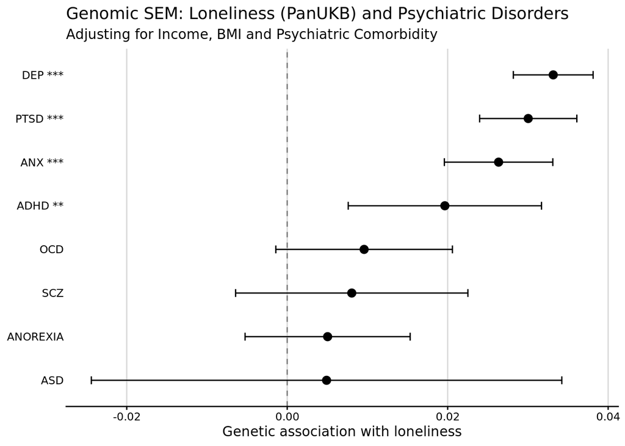

- after adjusting for comorbid psychiatric conditions and income + BMI, depression, PTSD, anxiety, ADHD remain significantly associated with loneliness (genetically)

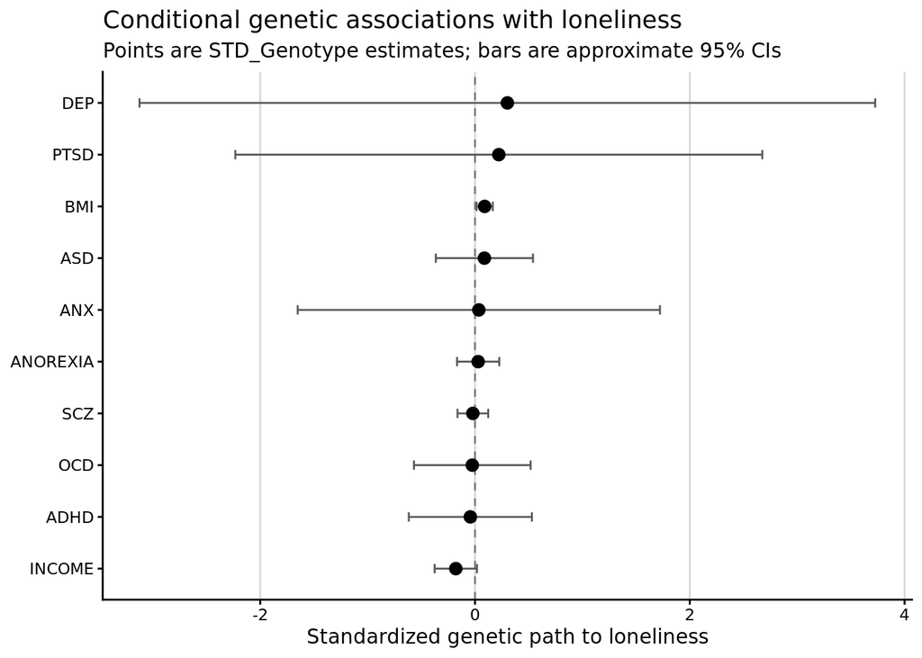

#### Sensitivity Analyses using just one of the internalizing disorders

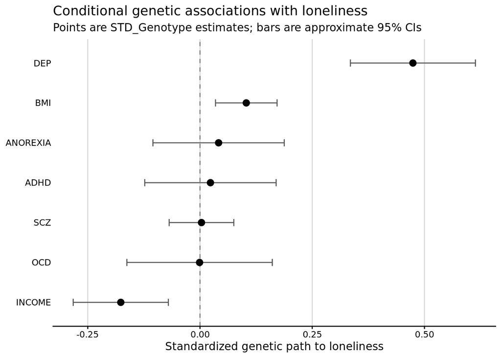

- when we exclude highly collinear traits (anx, ptsd) and just use depression, then we see that CI’s get more precise, and we see the expected association with depression and loneliness - for now, just going to use the unstandardized effect so we can see overall patterns and replicate the observational analsyes

#### Loneliness and Immune Biomarkers (Adjusted)

- excluding WBC, Basophil, TNF

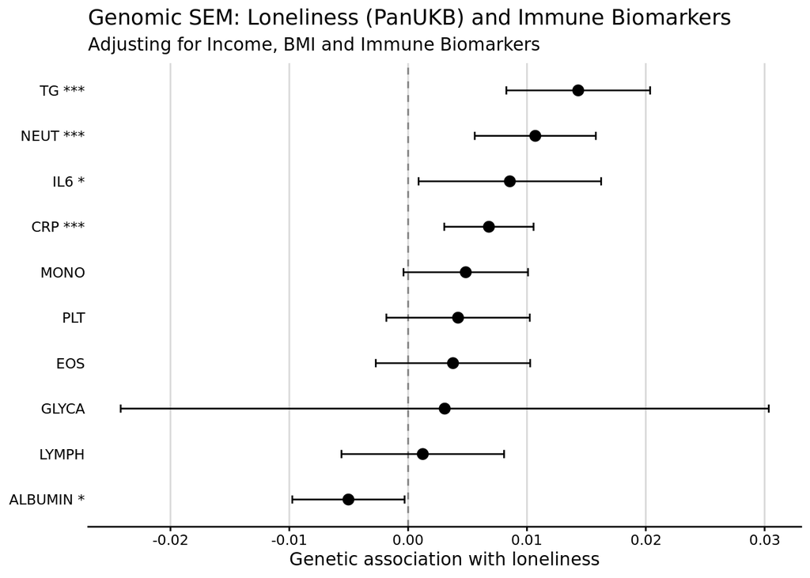

- after adjusting for income and BMI (and each other) the strongest associations with loneliness are triglycerides, IL-6, neutrophils and CRP

#### Loneliness and Immune Conditions

- excluding UC and Crohn’s

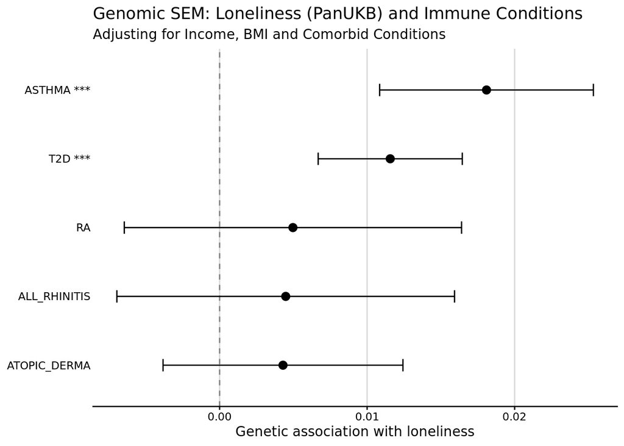

#### Fully adjusted model

- excluding anything that doesn’t remain in the previous models

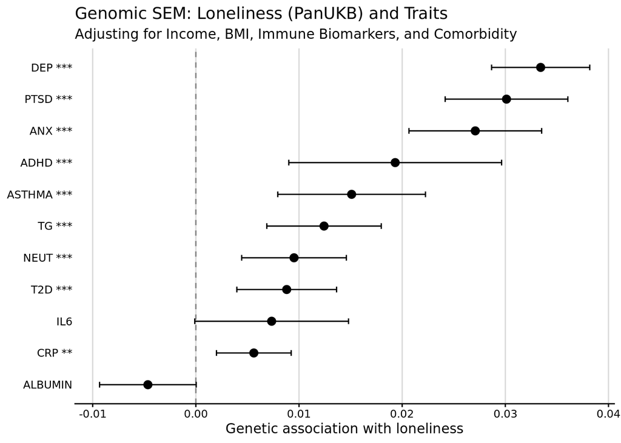

## Mediation Models

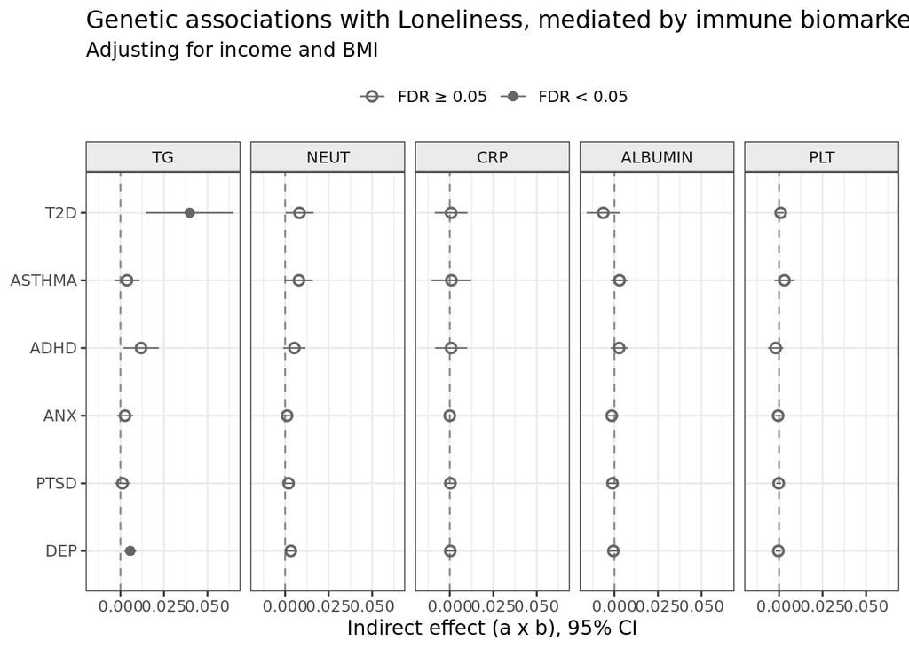

- triglycerides have a significant indirect effect on the association between loneliness and T2D, but the magnitude is very small
- all other immune biomarkers do not significantly genetically mediate this association.

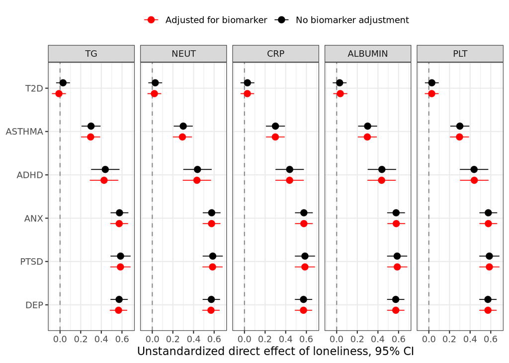

- As we saw in the observational models, we don’t see a significant attenuation effect - So while an indirect effect of triglycerides exists on Depression and T2D, it does not contribute meaningfully to the main effect

## Replication using AoU Loneliness

[figure not shown]

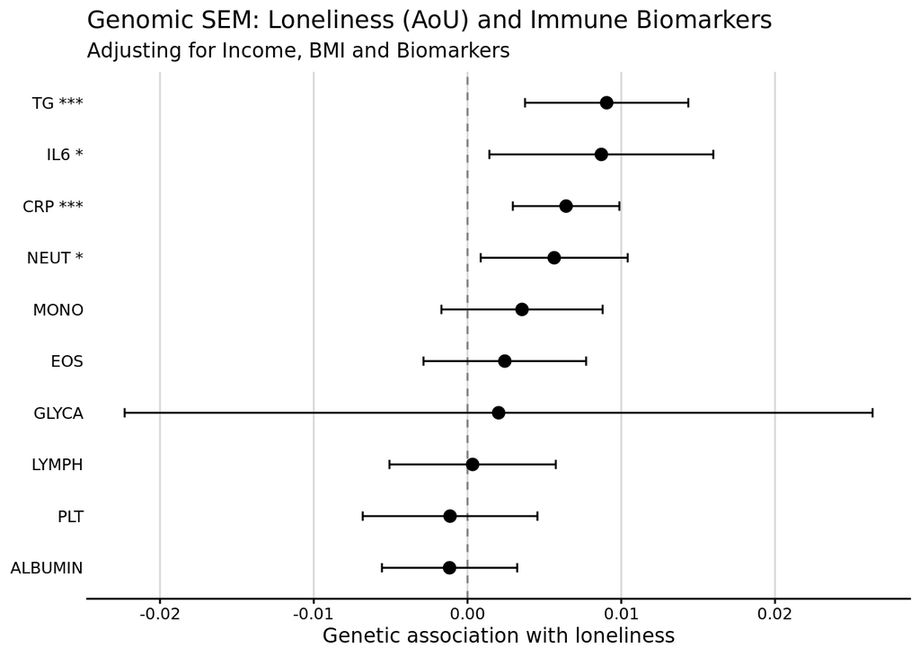

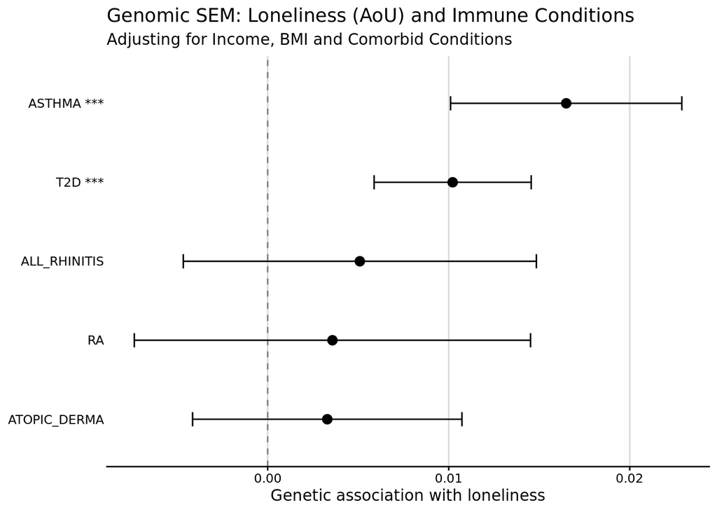

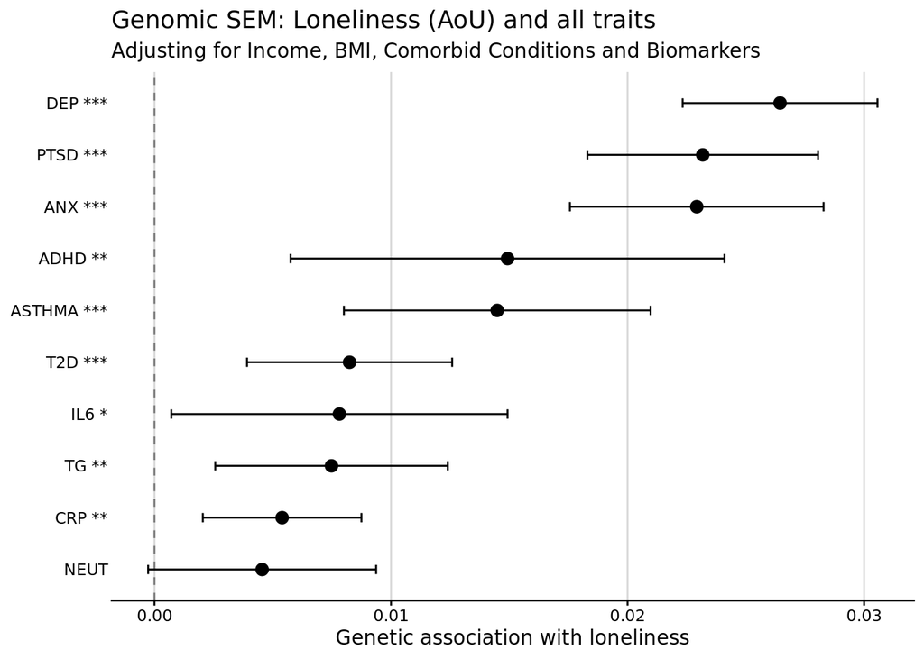

#### Replicating Mediation Analyses

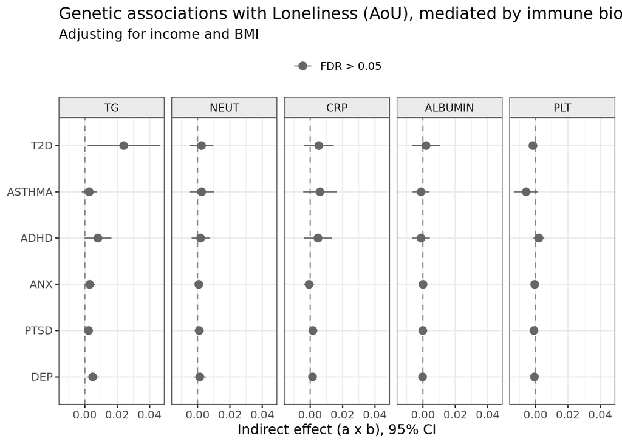

### Dual-Mediation Model

- Linking Depression -> T2D via loneliness and triglycerides

```
## [1] "Running primary model"
## [1] "Calculating Standardized Results"
## [1] "Calculating SRMR"
## elapsed
##   1.345
## [1] "Model fit statistics are all printed as NA as you have specified a fully saturated model (i.e., df = 0)"
```

|  | lhs | op | rhs | Unstand_Est | Unstand_SE | STD_Genotype | STD_Genotype_SE | STD_All | p_value |
| --- | --- | --- | --- | --- | --- | --- | --- | --- | --- |
| 23 | TG | ~ | DEP | 0.192 | 0.030 | 0.127 | 0.020 | 0.127 | 0.000 |
| 24 | TG | ~ | INCOME | -0.180 | 0.031 | -0.124 | 0.021 | -0.124 | 0.000 |
| 22 | TG | ~ | BMI | 0.250 | 0.018 | 0.289 | 0.020 | 0.289 | 0.000 |
| 12 | LONELY | ~ | DEP | 0.738 | 0.033 | 0.627 | 0.028 | 0.627 | 0.000 |
| 13 | LONELY | ~ | INCOME | -0.193 | 0.037 | -0.170 | 0.033 | -0.170 | 0.000 |
| 11 | LONELY | ~ | BMI | 0.063 | 0.016 | 0.093 | 0.024 | 0.093 | 0.000 |
| 19 | T2D | ~ | TG | 0.321 | 0.038 | 0.342 | 0.041 | 0.342 | 0.000 |
| 18 | T2D | ~ | LONELY | -0.088 | 0.066 | -0.073 | 0.055 | -0.073 | 0.181 |
| 16 | T2D | ~ | DEP | 0.136 | 0.067 | 0.096 | 0.047 | 0.096 | 0.041 |
| 17 | T2D | ~ | INCOME | -0.028 | 0.031 | -0.021 | 0.022 | -0.021 | 0.351 |
| 15 | T2D | ~ | BMI | 0.360 | 0.018 | 0.443 | 0.023 | 0.443 | 0.000 |

|  | lhs | Unstand_Est | Unstand_SE | p_value |
| --- | --- | --- | --- | --- |
| 8 | ind_TG | 0.062 | 0.012 | 0.000 |
| 7 | ind_LONELY | -0.065 | 0.049 | 0.186 |
| 9 | ind_total | -0.004 | 0.052 | 0.945 |

#### Specific Mediation Model

- T2D -> Triglycerides -> Loneliness
- actually this ends up being the exact same estimate as Loneliness -> Triglycerides -> T2D (mathematically)

```
## [1] "Running primary model"
## [1] "Calculating Standardized Results"
## [1] "Calculating SRMR"
## elapsed
##   1.578
## [1] "Model fit statistics are all printed as NA as you have specified a fully saturated model (i.e., df = 0)"
```

|  | lhs | op | rhs | Unstand_Est | Unstand_SE | STD_Genotype | STD_Genotype_SE | STD_All | p_value |
| --- | --- | --- | --- | --- | --- | --- | --- | --- | --- |
| 10 | LONELY | ~ | T2D | -0.011 | 0.034 | -0.013 | 0.041 | -0.013 | 0.749 |
| 11 | LONELY | ~ | TG | 0.074 | 0.026 | 0.095 | 0.033 | 0.095 | 0.004 |
| 9 | LONELY | ~ | INCOME | -0.396 | 0.029 | -0.350 | 0.026 | -0.350 | 0.000 |
| 8 | LONELY | ~ | BMI | 0.078 | 0.024 | 0.116 | 0.035 | 0.116 | 0.001 |
| 16 | TG | ~ | T2D | 0.471 | 0.047 | 0.442 | 0.044 | 0.442 | 0.000 |
| 15 | TG | ~ | INCOME | -0.186 | 0.028 | -0.128 | 0.019 | -0.128 | 0.000 |
| 14 | TG | ~ | BMI | 0.051 | 0.032 | 0.059 | 0.037 | 0.059 | 0.109 |

#### Figuring out what causes platelets n.s.

```
## [1] "Running primary model"
## [1] "Calculating Standardized Results"
## [1] "Calculating SRMR"
## elapsed
##   2.591
```

```
## $modelfit
##       chisq df p_chisq      AIC       CFI     SRMR
## df 461197.9 19       0 461341.9 -119.3933 3.561566
##
## $results
##           lhs op       rhs   Unstand_Est          Unstand_SE STD_Genotype
## 56   LONELY_F  ~     PLT_F  0.0058501808 0.00310075340365728  0.015897237
## 53   LONELY_F  ~  INCOME_F -0.0245207026 0.00228738192761913 -0.346252738
## 51   LONELY_F  ~     BMI_F  0.0206282531 0.00318637674993299  0.157321244
## 54   LONELY_F  ~   LYMPH_F  0.0027644142 0.00349788988721741  0.020793640
## 52   LONELY_F  ~     EOS_F  0.0051424364   0.003367078110153  0.016839571
## 55   LONELY_F  ~    MONO_F  0.0070882132 0.00277914418408251  0.015690838
## 62    LYMPH_F ~~     EOS_F  0.0417511588 0.00506726483638106  0.254252228
## 67    LYMPH_F ~~    MONO_F  0.0651771649 0.00484842092597593  0.383366383
## 68    LYMPH_F ~~    NEUT_F  0.0473779561 0.00383403355441499  0.300199575
```

[output cut: 214 more lines]

- when we add monocytes (on top of income, bmi, lymph and eosinophils), platelets no longer significantly associated with loneliness - because they are quite strongly correlated
- could potentially combine them all into a latent factor, then try a mediating model